# MUSA508-Leah-Palak

Leah Shapiro & Palak Agarwal

October 16th, 2020

# Introduction

Zillow publishes “Zestimate” valuations for homes across the U.S. using an algorithm that draws on data from county and tax assessor records, multiple listing services, brokerages, and homeowner submissions. This project sought to improve Zillow’s housing market predictions for Miami and Miami Beach.

This endeavor was challenging for several reasons. First, we relied exlusively on ordinary least squares linear modeling. A more sophisted algorithm, such as random forest, may produce a better model. Second, the project used only open source data. This restriction was particularly challenging given the lack of open source data available for Miami Beach as compared to Miami.

We conceptualized our model using the hedonic model, which predicts home prices by summing the value of its constituent parts. Our model includes three types of variables: internal characteristics of houses, amenities/public services, and spatial structures.

Despite our hardwork and dedication to the project, we failed to create a successful model. With a mean absolute error of over $350,000 in our model, we do not anticipate securing a contract with Zillow anytime soon.

### Set Up

```r
#importing the library
library(rjson)
library(tidycensus)
library(tidyverse)
library(sf)
library(spdep)
library(caret)
library(ckanr)
library(FNN)
library(grid)
library(gridExtra)
library(ggcorrplot)
library(jtools)
library(viridis)
library(kableExtra)
library(rlist)
library(dplyr)
library(osmdata)
library(geosphere)
library(fastDummies)
library(FNN)
library(viridis)
library(stargazer)
options(scipen=999)
options(tigris_class = "sf")
```

### Themes, Palettes, and Quantile Break Functions

```r
# Themes and Functions
mapTheme <- function(base_size = 12) {
  theme(
    text = element_text( color = "black"),
    plot.title = element_text(size = 14,colour = "black"),
    plot.subtitle=element_text(face="italic"),
    plot.caption=element_text(hjust=0),
    axis.ticks = element_blank(),
    panel.background = element_blank(),axis.title = element_blank(),
    axis.text = element_blank(),
    axis.title.x = element_blank(),
    axis.title.y = element_blank(),
    panel.grid.minor = element_blank(),
    panel.border = element_rect(colour = "black", fill=NA, size=2)
  )
}
plotTheme <- function(base_size = 12) {
  theme(
    text = element_text( color = "black"),
    plot.title = element_text(size = 14,colour = "black"),
    plot.subtitle = element_text(face="italic"),
    plot.caption = element_text(hjust=0),
    axis.ticks = element_blank(),
    panel.background = element_blank(),
    panel.grid.major = element_line("grey80", size = 0.1),
    panel.grid.minor = element_blank(),
    panel.border = element_rect(colour = "black", fill=NA, size=2),
    strip.background = element_rect(fill = "grey80", color = "white"),
    strip.text = element_text(size=12),
    axis.title = element_text(size=12),
    axis.text = element_text(size=10),
    plot.background = element_blank(),
    legend.background = element_blank(),
    legend.title = element_text(colour = "black", face = "italic"),
    legend.text = element_text(colour = "black", face = "italic"),
    strip.text.x = element_text(size = 14)
  )
}
palette5 <- c("#25CB10", "#5AB60C", "#8FA108",   "#C48C04", "#FA7800")
qBr <- function(df, variable, rnd) {
  if (missing(rnd)) {
    as.character(quantile(round(df[[variable]],0),
                          c(.01,.2,.4,.6,.8), na.rm=T))
  } else if (rnd == FALSE | rnd == F) {
    as.character(formatC(quantile(df[[variable]]), digits = 3),
                 c(.01,.2,.4,.6,.8), na.rm=T)
  }
}
q5 <- function(variable) {as.factor(ntile(variable, 5))}
```

### Additional Functions

Many of the features in this model were engineered using two functions: **Nearest neighbor** and **Multiple ring buffer.** The nearest neighbor function finds the average distance from the measuring feature to the measured feature. The function requires 3 input variables - the dependent feature to measure from, the features to measure to, and the number of features. For example, a nearest neighbor feature could measure the average distance from each house to its three closest public parks.

The multiple ring buffer creates concentric rings around point features. This can be used, for example, to determine how many houses are within a .5 mile radius of a metro stop.

```r
# Functions
nn_function <- function(measureFrom,measureTo,k) {
  measureFrom_Matrix <- as.matrix(measureFrom)
  measureTo_Matrix <- as.matrix(measureTo)
  nn <-
    get.knnx(measureTo, measureFrom, k)$nn.dist
  output <-
    as.data.frame(nn) %>%
    rownames_to_column(var = "thisPoint") %>%
    gather(points, point_distance, V1:ncol(.)) %>%
    arrange(as.numeric(thisPoint)) %>%
    group_by(thisPoint) %>%
    summarize(pointDistance = mean(point_distance)) %>%
    arrange(as.numeric(thisPoint)) %>%
    dplyr::select(-thisPoint) %>%
    pull()

  return(output)
}
#Function MultipleRingBuffer
multipleRingBuffer <- function(inputPolygon, maxDistance, interval)
{
  #create a list of distances that we'll iterate through to create each ring
  distances <- seq(0, maxDistance, interval)
  #we'll start with the second value in that list - the first is '0'
  distancesCounter <- 2
  #total number of rings we're going to create
  numberOfRings <- floor(maxDistance / interval)
  #a counter of number of rings
  numberOfRingsCounter <- 1
  #initialize an otuput data frame (that is not an sf)
  allRings <- data.frame()

  #while number of rings  counteris less than the specified nubmer of rings
  while (numberOfRingsCounter <= numberOfRings)
  {
    #if we're interested in a negative buffer and this is the first buffer
    #(ie. not distance = '0' in the distances list)
    if(distances[distancesCounter] < 0 & distancesCounter == 2)
    {
      #buffer the input by the first distance
      buffer1 <- st_buffer(inputPolygon, distances[distancesCounter])
      #different that buffer from the input polygon to get the first ring
      buffer1_ <- st_difference(inputPolygon, buffer1)
      #cast this sf as a polygon geometry type
      thisRing <- st_cast(buffer1_, "POLYGON")
      #take the last column which is 'geometry'
      thisRing <- as.data.frame(thisRing[,ncol(thisRing)])
      #add a new field, 'distance' so we know how far the distance is for a give ring
      thisRing$distance <- distances[distancesCounter]
    }


    #otherwise, if this is the second or more ring (and a negative buffer)
    else if(distances[distancesCounter] < 0 & distancesCounter > 2)
    {
      #buffer by a specific distance
      buffer1 <- st_buffer(inputPolygon, distances[distancesCounter])
      #create the next smallest buffer
      buffer2 <- st_buffer(inputPolygon, distances[distancesCounter-1])
      #This can then be used to difference out a buffer running from 660 to 1320
      #This works because differencing 1320ft by 660ft = a buffer between 660 & 1320.
      #bc the area after 660ft in buffer2 = NA.
      thisRing <- st_difference(buffer2,buffer1)
      #cast as apolygon
      thisRing <- st_cast(thisRing, "POLYGON")
      #get the last field
      thisRing <- as.data.frame(thisRing$geometry)
      #create the distance field
      thisRing$distance <- distances[distancesCounter]
    }

    #Otherwise, if its a positive buffer
    else
    {
      #Create a positive buffer
      buffer1 <- st_buffer(inputPolygon, distances[distancesCounter])
      #create a positive buffer that is one distance smaller. So if its the first buffer
      #distance, buffer1_ will = 0.
      buffer1_ <- st_buffer(inputPolygon, distances[distancesCounter-1])
      #difference the two buffers
      thisRing <- st_difference(buffer1,buffer1_)
      #cast as a polygon
      thisRing <- st_cast(thisRing, "POLYGON")
      #geometry column as a data frame
      thisRing <- as.data.frame(thisRing[,ncol(thisRing)])
      #add the distance
      thisRing$distance <- distances[distancesCounter]
    }

    #rbind this ring to the rest of the rings
    allRings <- rbind(allRings, thisRing)
    #iterate the distance counter
    distancesCounter <- distancesCounter + 1
    #iterate the number of rings counter
    numberOfRingsCounter <- numberOfRingsCounter + 1
  }

  #convert the allRings data frame to an sf data frame
  allRings <- st_as_sf(allRings)
}
```

# Data Wrangling

## Data

### Internal Characteristics

First we looked at the internal characteristics of the houses. We considered features associated with the number of bedrooms, number of bathrooms, living square feet, actual square feet, year built, effective year built, stories, pools, jacuzzis, fences, patios, docks, and elevators. For number of bedrooms and year built, we tested both discrete and categorical variables in our model.

### Amenities/Public services

Proximity to public services and amenities can add value to houses. To get this data we made use of Open Street map as well as other open data portals. We considered the following public services and amenities when building our model:  
* **Transit Stops**  
* **Restaurants, cafes and bars**  
* **Schools**  
* **School Attendance Areas** : This information was not available for Miami Beach  
* **Parks**  
* **Places of worship**  
* **Car Parks**  
* **Work Centers**  
* **Hospitals**

### Spatial Structures

In creating our model, we experimented with spatial features at various scales:  
* **Neighborhood**: We were not able to find a neighborhood shapefile for Miami Beach, so we use Miami Beach’s municipality borders as a proxy. One house was initially not assigned a neighborhood, so we imputed the value “Haynesworth” based on the house’s location on the map.  
* **Zip Code**  
* **City**  
* **Shoreline**  
* **Sale Price of nearest 5 houses**  
* **Median Rent within Census Tract**  
* **Median Income within Census Tract**: The mean median income was used for missing values  
* **Racial Composition within Census Tract**: Like many cities within the U.S., Miami is highly segregated.

## Variable Descriptions

The following variables were ultimately included in our model.

### Numeric Internal Features

| Internal_Characteristics | Description | Mean | Median | Max | Min | Standard_Deviation |
| --- | --- | --- | --- | --- | --- | --- |
| LivingSqFt | Living Sq Ft | 2011.431059 | 1632.00 | 18006 | 288 | 1369.2473426 |
| EffectiveYearBuilt | Age adjusted for Renovation or neglect | 1973.362832 | 1975.00 | 2019 | 1905 | 26.5641355 |
| SalePrice | Last sale price | 730835.912075 | 332500.00 | 27750000 | 0 | 1822987.7886706 |
| ActualSqFt | Updated Living SqFt | 2367.747645 | 1884.00 | 20192 | 388 | 1732.3170408 |
| LotSize | Size of the Lot | 7657.781347 | 6693.75 | 80664 | 1250 | 4401.4024951 |
| Bath | Number of Bathrooms | 2.109620 | 2.00 | 12 | 0 | 1.2986293 |
| Stories | Number of Stories | 1.206680 | 1.00 | 4 | 0 | 0.4420643 |
| Bed | Number of Bedrooms | 3.035398 | 3.00 | 13 | 0 | 1.0919479 |

Summary Statistics of Internal Characteristics  
Table 1.1

### Categorical Internal Features

| Amenities | Description | Count |
| --- | --- | --- |
| Docks | Presence of a dock | 684 |
| Luxury Pool | Presence of a luxury pool | 7 |
| Whirlpool | Presence of a whirlpool | 40 |
| Elevators | Presence of an elevator | 364 |
| Fences | Presence of fences | 3 |
| Pool Type 1 | Presence of a 8ft pool | 7 |
| Pool Type 2 | Presence of a 2-4ft pool | 11 |
| Pool Type 3 | Presence of a 3-6ft pool | 2 |
| Pool Type 4 | Presence of a 3-8ft pool | 67 |

Count of Categorical Internal Features  
Table 1.2

### Ammenities/Public Services

| Amenities | Description | Mean | Median | Max | Min | Standard_Deviation |
| --- | --- | --- | --- | --- | --- | --- |
| Dist.Metro | Distance to the closest Metro stop | 2.1307082 | 1.416819 | 7.054678 | 0.0372621 | 1.7508759 |
| Dist.Restaurants | Average distance to the 5 closest restaurants | 0.6615725 | 0.626169 | 2.112204 | 0.0323645 | 0.3658257 |
| Dist.School | Distance to the closest school | 1228.0921477 | 968.478667 | 7653.552964 | 41.1676081 | 1128.9394913 |
| Dist.Worship | Distance to the closest place of worship | 2736.3433302 | 2280.558722 | 10085.689827 | 96.9273545 | 1752.9820224 |
| Dist.Parking | Average distance to two closest parking spots | 2299.7288593 | 1836.084798 | 10552.669874 | 75.3127690 | 1832.8067300 |
| Dist.WorkCenter | Average distance to ten work centers | 2309.9128575 | 1929.020305 | 7962.497260 | 388.8800188 | 1367.7064751 |
| Dist.Hospital | Distance to the closest hospital | 7138.1669146 | 6460.865236 | 20188.849300 | 88.8705949 | 4152.4067817 |

Summary Statistics of Amenities and public services  
Table 1.3

### Spatial Structures

| Amenities | Description | Mean | Median | Max | Min | Standard_Deviation |
| --- | --- | --- | --- | --- | --- | --- |
| Dist.Shore | Distance to coast | -0.8669539 | -0.7315004 | 1.690956 | -8.300917 | 1.614161 |
| Lag_Price | Average price of the 5 closest houses | 607303.7567799 | 343800.0000000 | 9733000.000000 | 0.000000 | 910008.467836 |
| Median_Rent | Median Rent according to the census tract | 1133.0380195 | 1061.0000000 | 2271.000000 | 245.000000 | 428.221642 |
| Median_Income | Median Income according to the census tract | 59223.6838938 | 39821.0000000 | 172750.000000 | 14699.000000 | 44963.056660 |
| Pct_white | Percentage of White residents | 74.0446888 | 89.8468787 | 98.543548 | 5.753497 | 29.387571 |
| Pct_Hispanic | Percentage of Hispanic residents | 57.7175499 | 48.0920478 | 102.200721 | 8.747937 | 30.364491 |

Summary Statistics of Spatail Structures  
Table 1.4

# Methods

Models can be judged by their accuracy or their generalizability. The accuracy of a model reflects how close predicted values are to the observed values. This can be measured by the adjusted R-squared, which tells us how much of the variation in the dependent variable, house prices, is explained by the independent variables in the model.

FOr the purpose of this project, we attempted to maximize our model’s generalizability. A generalizable model is one that can successfully predict on new data. To determine our models’ generalizability, we randomly split our data into a training set and a testing set. We then performed a stepwise regression, adding one dependent variable at a time and determining whether the mean absolute error (MAE) of the model went up or down.

## Correlation Matrix

The presence of highly correlated, or colinear, variables in a model can lead to unwanted redundancy. We used the correlation matrix below to determine which variables are colinear.

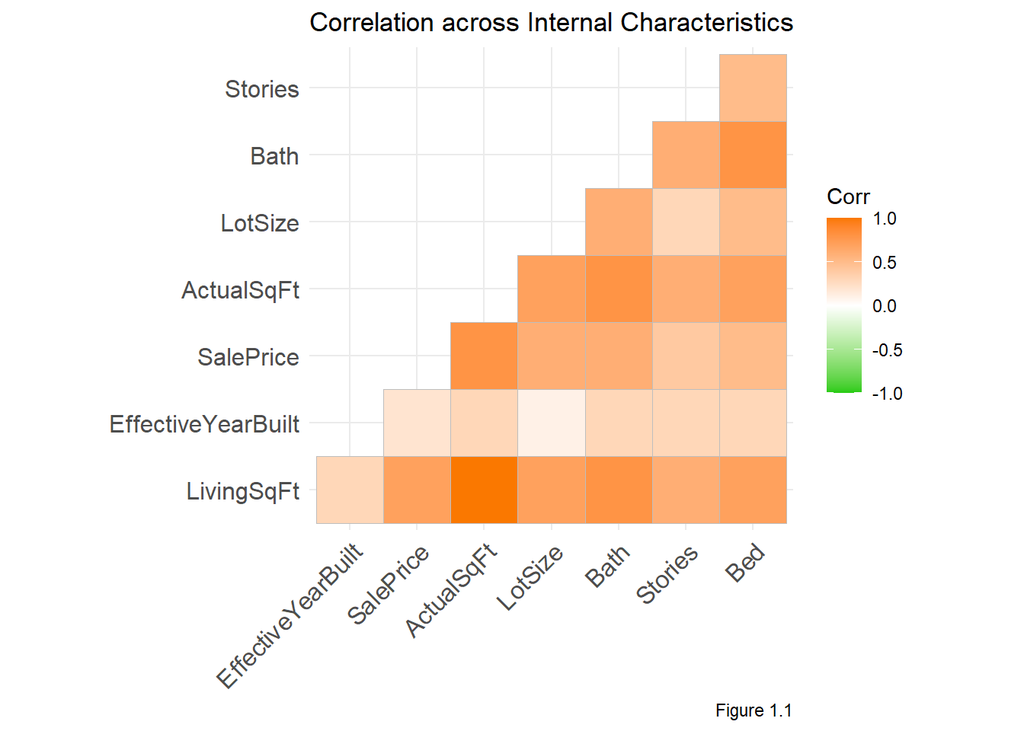

```r
## Correlation matrix

numericVars1 <-
  select_if(st_drop_geometry(MiamiDF), is.numeric) %>% na.omit() %>%
  dplyr::select(LivingSqFt,EffectiveYearBuilt,SalePrice,ActualSqFt,LotSize,Bath,Stories,Bed)

ggcorrplot(
  round(cor(numericVars1), 1),
  p.mat = cor_pmat(numericVars1),
  colors = c("#25CB10", "white", "#FA7800"),
  type="lower",
  insig = "blank") +
  labs(title = "Correlation across Internal Characteristics", caption="Figure 1.1")
```

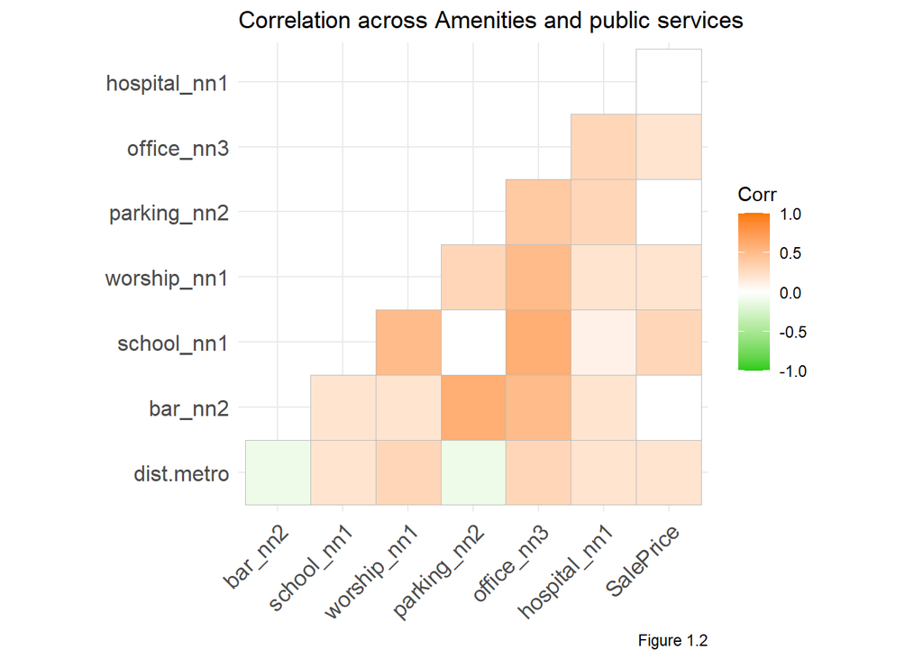

```r
numericVars2 <-
  select_if(st_drop_geometry(MiamiDF), is.numeric) %>% na.omit() %>%
  dplyr::select(dist.metro,bar_nn2,school_nn1,worship_nn1,parking_nn2,office_nn3,hospital_nn1, SalePrice)

ggcorrplot(
  round(cor(numericVars2), 1),
  p.mat = cor_pmat(numericVars2),
  colors = c("#25CB10", "white", "#FA7800"),
  type="lower",
  insig = "blank") +
  labs(title = "Correlation across Amenities and public services", caption="Figure 1.2")
```

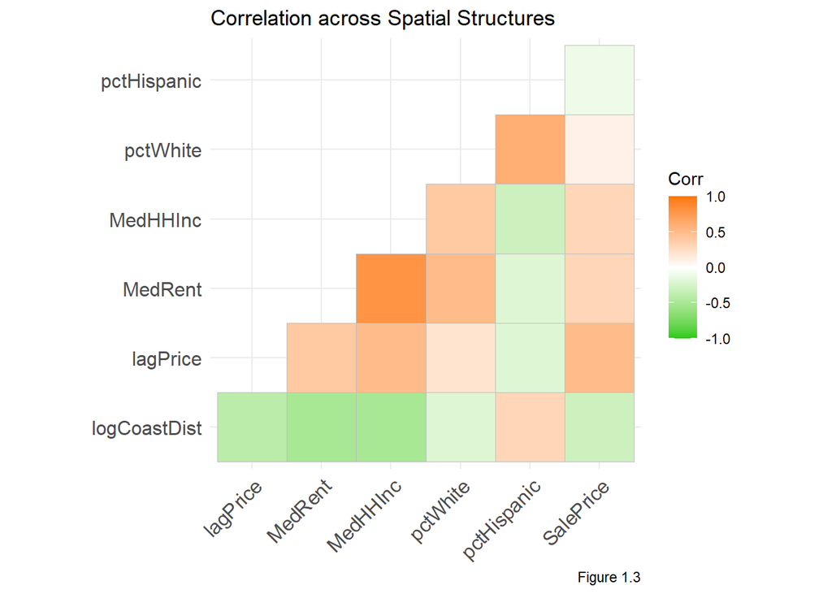

```r
numericVars3 <-
  select_if(st_drop_geometry(MiamiDF), is.numeric) %>% na.omit() %>%
  dplyr::select(logCoastDist,lagPrice,MedRent,MedHHInc,pctWhite,pctHispanic, SalePrice)

ggcorrplot(
  round(cor(numericVars3), 1),
  p.mat = cor_pmat(numericVars3),
  colors = c("#25CB10", "white", "#FA7800"),
  type="lower",
  insig = "blank") +
  labs(title = "Correlation across Spatial Structures", caption="Figure 1.3")
```

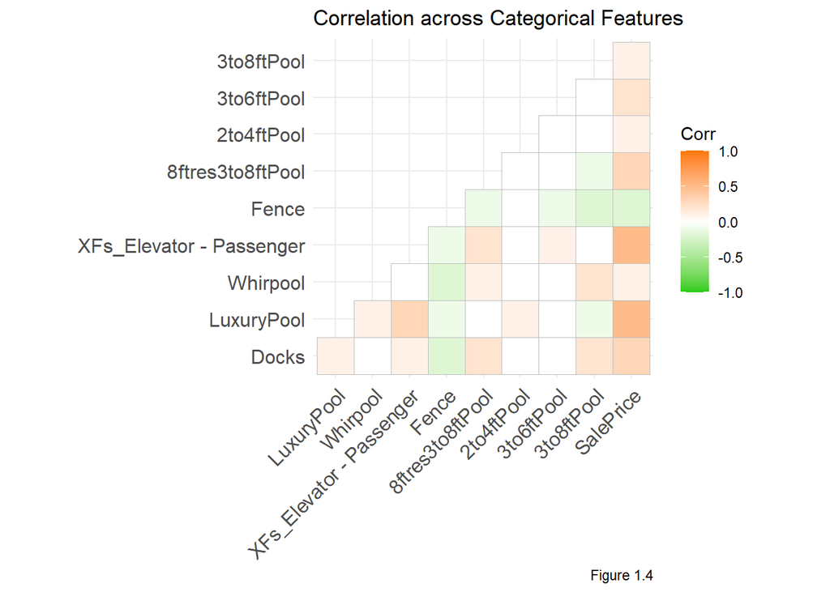

```r
numericVars4 <-
  select_if(st_drop_geometry(MiamiDF), is.numeric) %>% na.omit() %>%
  dplyr::select(Docks, LuxuryPool, Whirpool, `XFs_Elevator - Passenger`, Fence, `8ftres3to8ftPool`,`2to4ftPool`,
         `3to6ftPool`,`3to8ftPool`, SalePrice)

ggcorrplot(
  round(cor(numericVars4), 1),
  p.mat = cor_pmat(numericVars4),
  colors = c("#25CB10", "white", "#FA7800"),
  type="lower",
  insig = "blank") +
  labs(title = "Correlation across Categorical Features", caption="Figure 1.4")
```

## Home Price Correlation Scatter Plots

To help us identify which variables might be most important to include in our model, we generated the following scatter plots visualizing the correlation between independent variables and home sale prices.

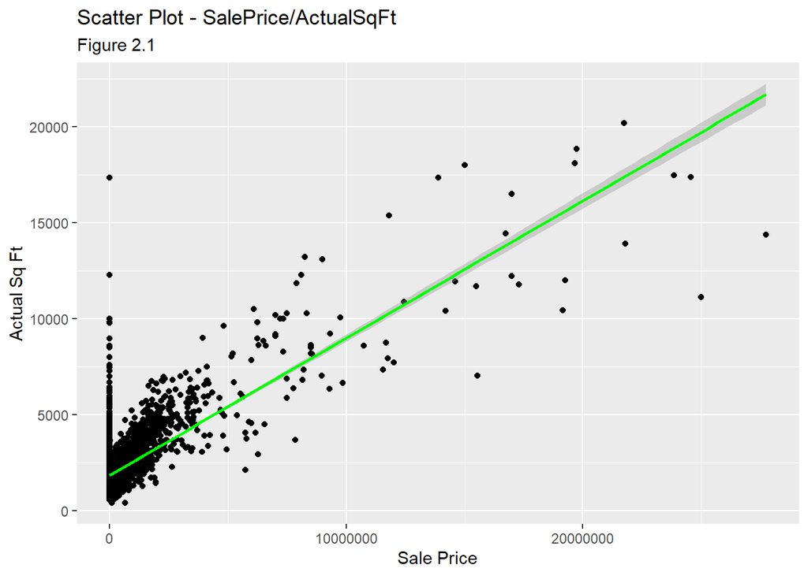

```r
ggplot(MiamiDF, aes(x = SalePrice, y = ActualSqFt)) +
  geom_point() +
  geom_smooth(method = "lm", color = "green") +
  labs(title = "Scatter Plot - SalePrice/ActualSqFt",
       x = "Sale Price",
       y = "Actual Sq Ft",
       subtitle = "Figure 2.1") +
  theme(
    legend.position = "none"
  )
```

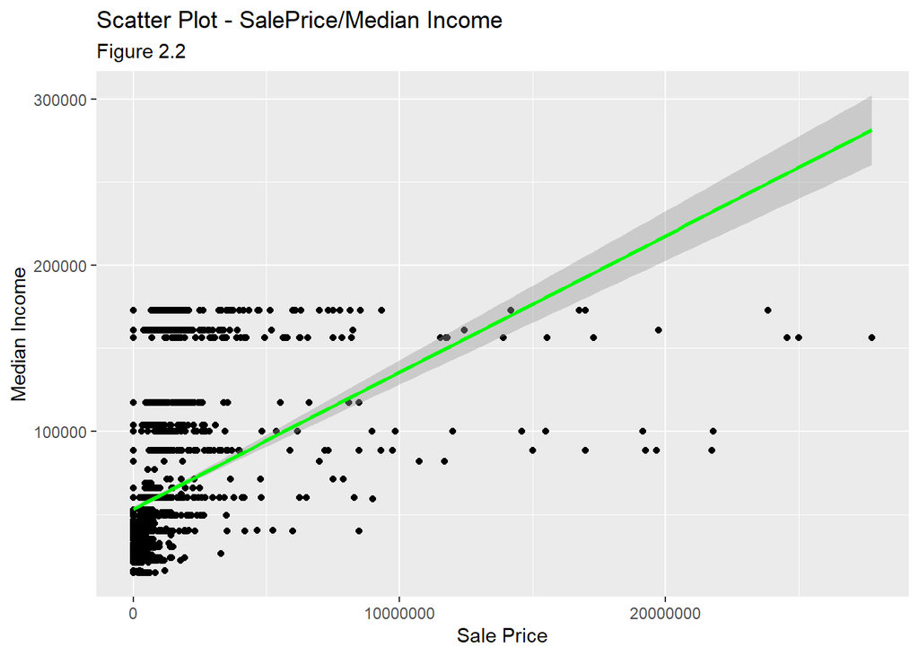

```r
ggplot(MiamiDF, aes(x = SalePrice, y = MedHHInc)) +
  geom_point() +
  geom_smooth(method = "lm", color = "green") +
  labs(title = "Scatter Plot - SalePrice/Median Income",
       x = "Sale Price",
       y = "Median Income",
       subtitle = "Figure 2.2") +
  theme(
    legend.position = "none"
  )
```

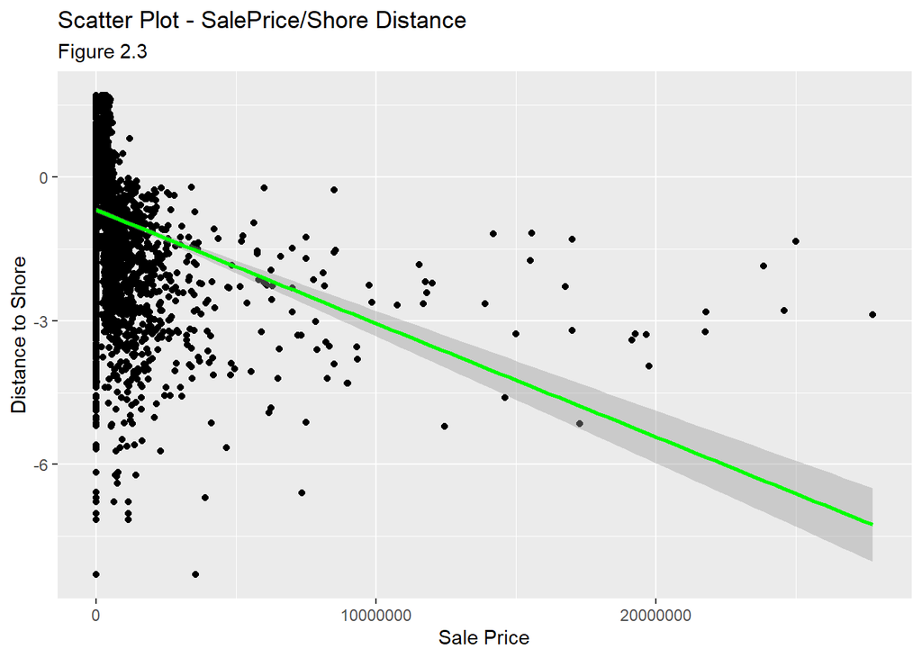

```r
ggplot(MiamiDF, aes(x = SalePrice, y = logCoastDist)) +
  geom_point() +
  geom_smooth(method = "lm", color = "green") +
  labs(title = "Scatter Plot - SalePrice/Shore Distance",
       x = "Sale Price",
       y = "Distance to Shore",
       subtitle = "Figure 2.3") +
  theme(
    legend.position = "none"
  )
```

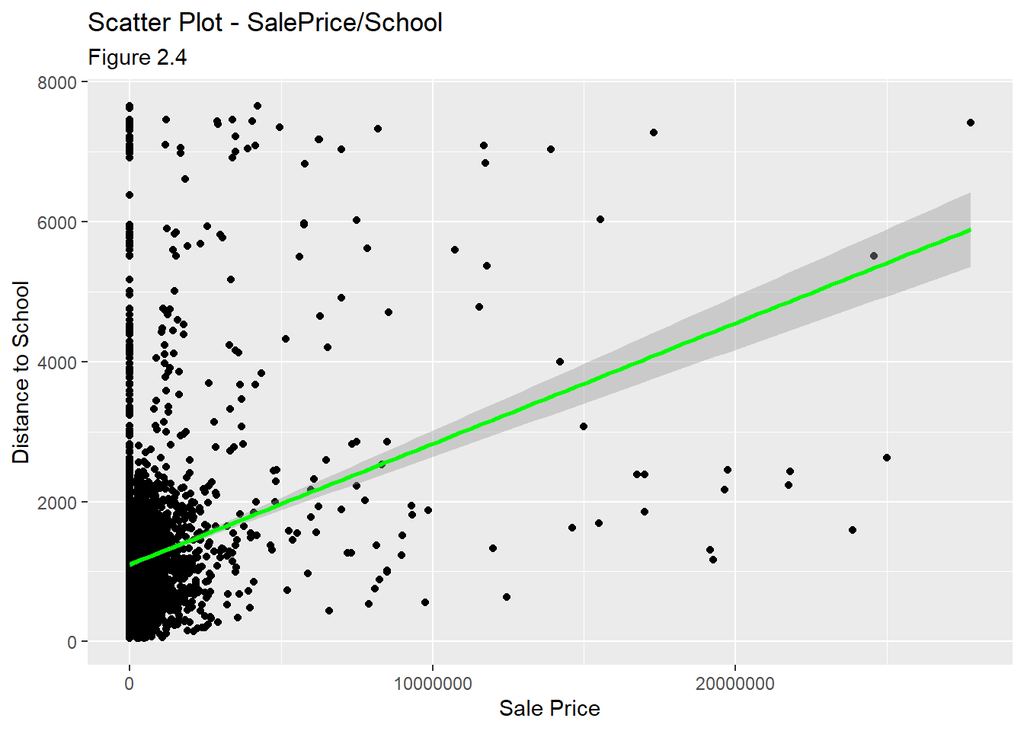

```r
ggplot(MiamiDF, aes(x = SalePrice, y = school_nn1)) +
  geom_point() +
  geom_smooth(method = "lm", color = "green") +
  labs(title = "Scatter Plot - SalePrice/School",
       x = "Sale Price",
       y = "Distance to School",
       subtitle = "Figure 2.4") +
  theme(
    legend.position = "none"
  )
```

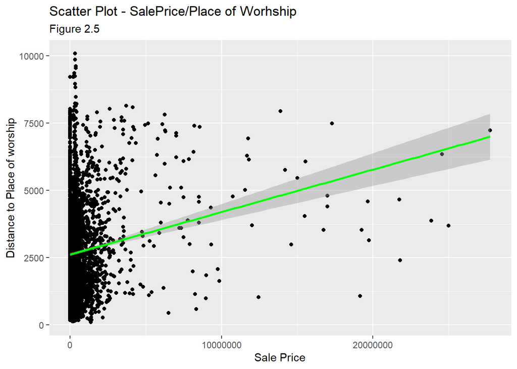

```r
ggplot(MiamiDF, aes(x = SalePrice, y = worship_nn1)) +
  geom_point() +
  geom_smooth(method = "lm", color = "green") +
  labs(title = "Scatter Plot - SalePrice/Place of Worhship",
       x = "Sale Price",
       y = "Distance to Place of worship",
       subtitle = "Figure 2.5") +
  theme(
    legend.position = "none"
  )
```

## Maps

The following map visualizes sale prices from the data set we used to train our model. The clustering of sale prices gave us an idea about certain spatial relationships which we used to identify our independent variables.

### Sale Price Map

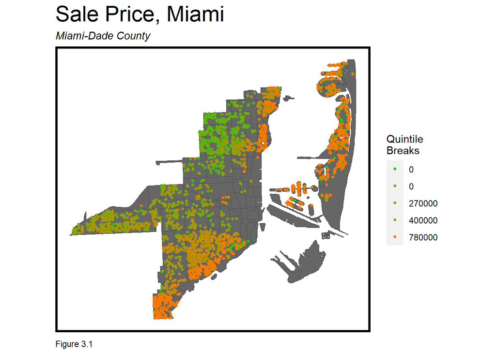

```r
### Sale Price
ggplot() +
  geom_sf(data = Neighborhoods_combine, fill = "grey40") +
  geom_sf(data = MiamiDF, aes(colour = q5(SalePrice)),
          show.legend = "point", size = 1) +
  scale_colour_manual(values=palette5,
                      labels=qBr(MiamiDF,"SalePrice"),
                      name="Quintile\nBreaks") +
  labs(title="Sale Price, Miami", subtitle = "Miami-Dade County", caption="Figure 3.1") +
  mapTheme()+
  theme(plot.title = element_text(size=22))
```

### Independent Variable Maps

The first two maps represent the racial segregation in Miami and Miami Beach. While we were hesitant to use racial data in our model,including the spatial structure of segregation improved our model’s generalizability. The third map shows the location of the metro stops. Although we didn’t find a strong correlation between distance to metro stops and home sale prices, we still found that inclusion of this variable improved our model.

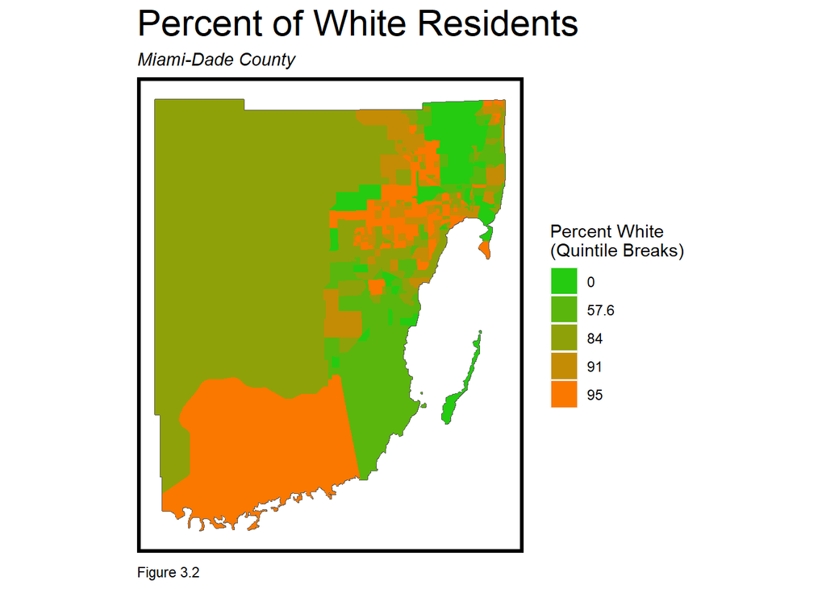

```r
## Percent White
ggplot(Miamitracts)+
  geom_sf(data = Miamitracts)+
  geom_sf(aes(fill = q5(pctWhite)), color = "transparent") +
  scale_fill_manual(values = palette5,
                    labels = qBr(Miamitracts, "pctWhite"),
                    name = "Percent White\n(Quintile Breaks)") +
  labs(title = "Percent of White Residents", subtitle = "Miami-Dade County", caption="Figure 3.2") +
  mapTheme() +
  theme(plot.title = element_text(size=22))
```

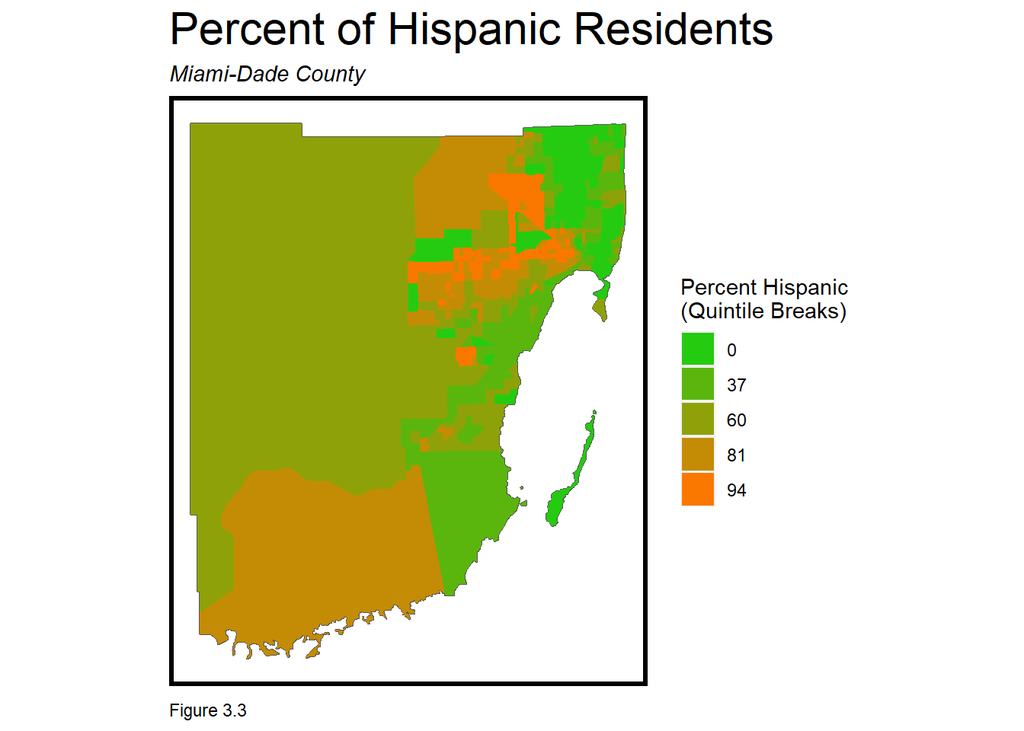

```r
## Percent Hispanic
ggplot(Miamitracts)+
  geom_sf(data = Miamitracts)+
  geom_sf(aes(fill = q5(pctHispanic)), color = "transparent") +
  scale_fill_manual(values = palette5,
                    labels = qBr(Miamitracts, "pctHispanic"),
                    name = "Percent Hispanic\n(Quintile Breaks)") +
  labs(title = "Percent of Hispanic Residents", subtitle = "Miami-Dade County", caption="Figure 3.3") +
  mapTheme() +
  theme(plot.title = element_text(size=22))
```

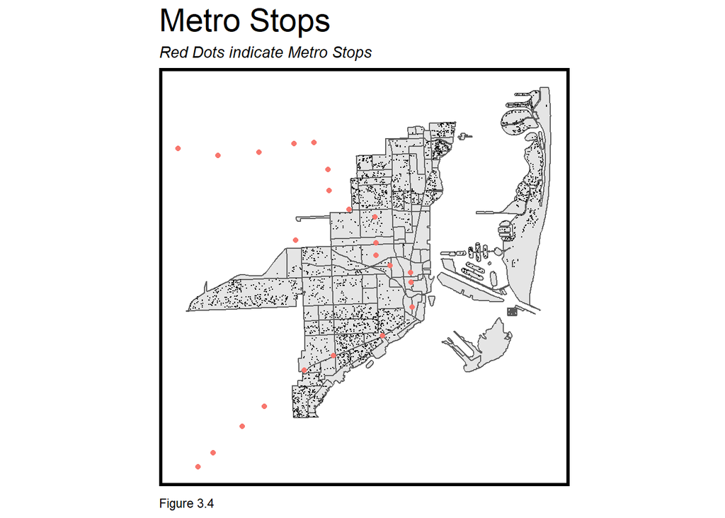

```r
## Metro Stations
ggplot() +
  geom_sf(data=Neighborhoods_combine)+
  geom_sf(data=MiamiDF, show.legend = FALSE, size = .1)+
  geom_sf(data=metroStops,
          aes(colour = 'red'),
          show.legend = FALSE) +
  labs(title = "Metro Stops", subtitle = "Red Dots indicate Metro Stops", caption="Figure 3.4") +
  mapTheme() +
  theme(plot.title = element_text(size=22))
```

# Results

### OLS Regression

#### Split dataframe into training and testing datasets

#### Regression and predicting Saleprice for test dataset

The output below provides a summary of our model. We experimented with different combinations of the independent variable to maximize generalizability as measured by MAE and accuracy measured by adjusted R sqaured.

| Observations | 1691 |
| --- | --- |
| Dependent variable | SalePrice |
| Type | OLS linear regression |

| F(153,1537) | 72.83 |
| --- | --- |
| R² | 0.88 |
| Adj. R² | 0.87 |

|  | Est. | S.E. | t val. | p |
| --- | --- | --- | --- | --- |
| (Intercept) | -4694950.77 | 2203133.71 | -2.13 | 0.03 |
| ActualSqFt | 581.61 | 32.27 | 18.02 | 0.00 |
| Neighbourhood_nameAllapattah Industrial District | 62671.24 | 1649271.41 | 0.04 | 0.97 |
| Neighbourhood_nameAuburndale | 169662.24 | 1503488.78 | 0.11 | 0.91 |
| Neighbourhood_nameBay Heights | -1360099.30 | 1392359.23 | -0.98 | 0.33 |
| Neighbourhood_nameBaypoint | -64691.79 | 1309668.45 | -0.05 | 0.96 |
| Neighbourhood_nameBayside | 607408.15 | 1291305.56 | 0.47 | 0.64 |
| Neighbourhood_nameBelle Island | -291922.83 | 1340222.88 | -0.22 | 0.83 |
| Neighbourhood_nameBelle Meade | 519902.91 | 1286935.13 | 0.40 | 0.69 |
| Neighbourhood_nameBelle Meade West | 633772.42 | 1302678.05 | 0.49 | 0.63 |
| Neighbourhood_nameBird Grove East | 102492.84 | 1388899.88 | 0.07 | 0.94 |
| Neighbourhood_nameBird Grove West | -330691.05 | 1327849.63 | -0.25 | 0.80 |
| Neighbourhood_nameBiscayne Island | 2775760.43 | 1494410.16 | 1.86 | 0.06 |
| Neighbourhood_nameBiscayne Plaza | -589886.21 | 1516906.37 | -0.39 | 0.70 |
| Neighbourhood_nameBrentwood | 784443.80 | 1721814.89 | 0.46 | 0.65 |
| Neighbourhood_nameBuena Vista Heights | 872194.56 | 1671131.59 | 0.52 | 0.60 |
| Neighbourhood_nameBuena Vista West | 617207.79 | 1657902.14 | 0.37 | 0.71 |
| Neighbourhood_nameCitrus Grove | -84937.74 | 1427559.69 | -0.06 | 0.95 |
| Neighbourhood_nameCivic Center | -42208.33 | 1609888.34 | -0.03 | 0.98 |
| Neighbourhood_nameCoral Gate | -210744.99 | 1438442.99 | -0.15 | 0.88 |
| Neighbourhood_nameCurtis Park | -149778.98 | 1596102.91 | -0.09 | 0.93 |
| Neighbourhood_nameDouglas Park | -472606.75 | 1365931.30 | -0.35 | 0.73 |
| Neighbourhood_nameEast Grove | -723089.44 | 1375626.57 | -0.53 | 0.60 |
| Neighbourhood_nameEast Little Havana | -72248.08 | 1397254.53 | -0.05 | 0.96 |
| Neighbourhood_nameEdgewater | 2541144.93 | 1817437.39 | 1.40 | 0.16 |
| Neighbourhood_nameEdison | 710044.60 | 1670527.06 | 0.43 | 0.67 |
| Neighbourhood_nameFair Isle | -61028.11 | 1391666.46 | -0.04 | 0.97 |
| Neighbourhood_nameFlagami | -263495.30 | 1530818.27 | -0.17 | 0.86 |
| Neighbourhood_nameFlora Park | -1081377.98 | 1447365.48 | -0.75 | 0.46 |
| Neighbourhood_nameGrove Center | -544813.94 | 1377003.22 | -0.40 | 0.69 |

[output cut: 130 more lines]

Standard errors: OLS

#### Accuracy - Mean Absolute Error

The following graph shows the distribution of absolute errors in our model. While most of our predictions are clustered at the low end of the graph, there are outliers of over $2,000,000 that are negatively impacting the MAE of the model.

```r
Miami.test <-
  Miami.test %>%
  mutate(SalePrice.Predict = predict(reg, Miami.test),
         SalePrice.Error = SalePrice.Predict - SalePrice,
         SalePrice.AbsError = abs(SalePrice.Predict - SalePrice),
         SalePrice.APE = (abs(SalePrice.Predict - SalePrice)) / SalePrice.Predict)

mean(Miami.test$SalePrice.AbsError, na.rm = T)
```

```
## [1] 360841.4
```

```r
mean(Miami.test$SalePrice.APE, na.rm = T)
```

```
## [1] 0.5451045
```

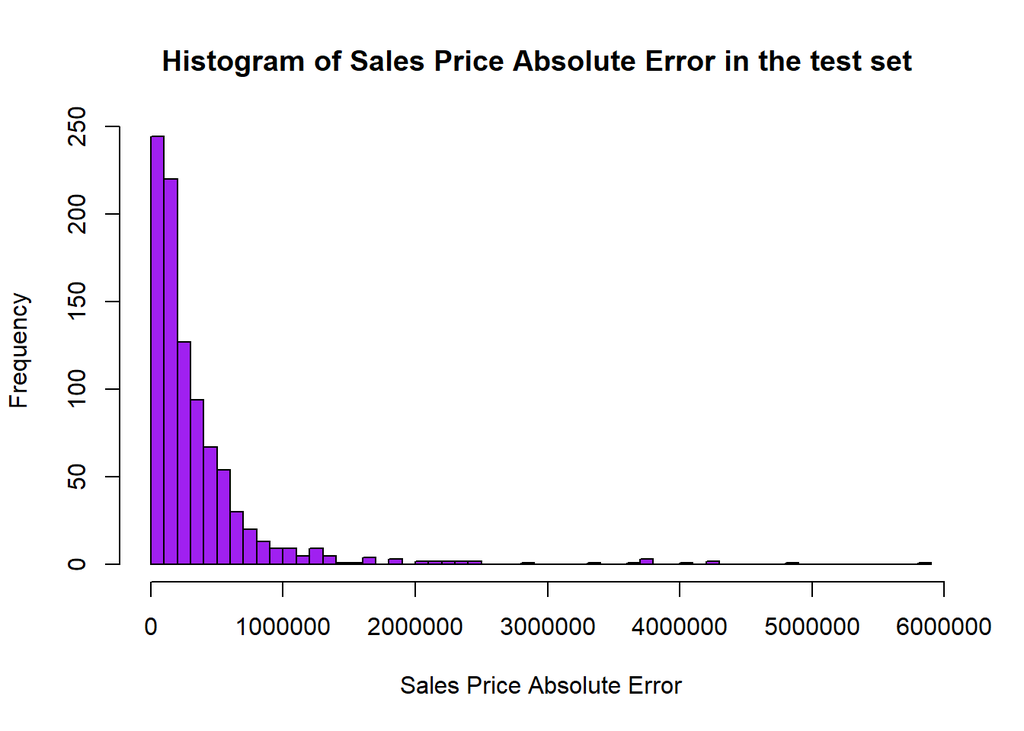

```r
hist(Miami.test$`SalePrice.AbsError`,xlab="Sales Price Absolute Error",
     breaks=50, col="purple", main = "Histogram of Sales Price Absolute Error in the test set ")
```

#### Table of MAE and MAPE

```r
rmse.train <- caret::MAE(predict(reg), Miami.training$SalePrice)
rmse.test  <- caret::MAE(reg_predict, Miami.test$SalePrice)

data.frame(DataSet = "Test set",
           Mean_Absolute_Error = mean(Miami.test$SalePrice.AbsError),
           Mean_Absolute_Percent_Error =mean(Miami.test$SalePrice.APE ))%>%
  kable() %>%
  kable_styling() %>%
  footnote(general_title = "Summary Statistics of Test dataset",
           general = "Table 2.1")
```

| DataSet | Mean_Absolute_Error | Mean_Absolute_Percent_Error |
| --- | --- | --- |
| Test set | 360841.4 | 0.5451045 |

Summary Statistics of Test dataset  
Table 2.1

#### Spatial Correlation of residuals

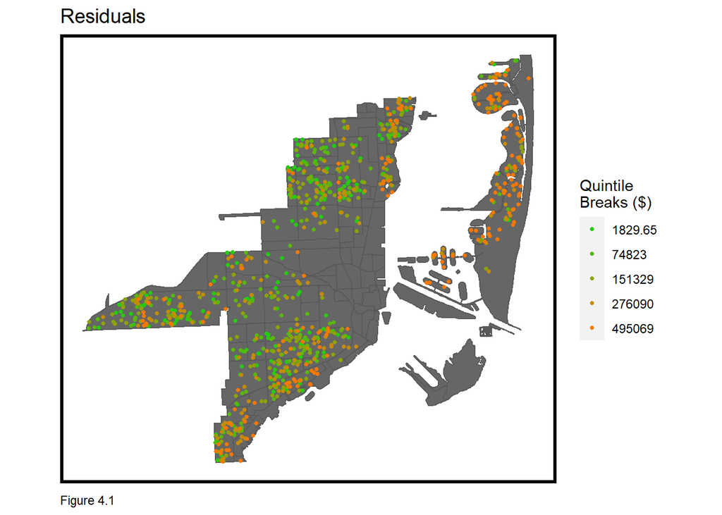

```r
ggplot() +
    geom_sf(data = Neighborhoods_combine, fill = "grey40") +
    geom_sf(data = Miami.test, aes(colour = q5(SalePrice.AbsError)),
            show.legend = "point", size = 1) +
    scale_colour_manual(values = palette5,
                     labels=qBr(Miami.test,"SalePrice.AbsError"),
                     name="Quintile\nBreaks ($)") +
    labs(title="Residuals", caption="Figure 4.1") +
    mapTheme()
```

#### Spatial Correlation of error

The first plot shows that as the price of a house increases, the prices of nearby houses also increase. This demonstrates the importance of including spatial features in our model.

The second plot shows that the errors of our model are also spatially clustered. This indicates that our model is missing important spatial features.

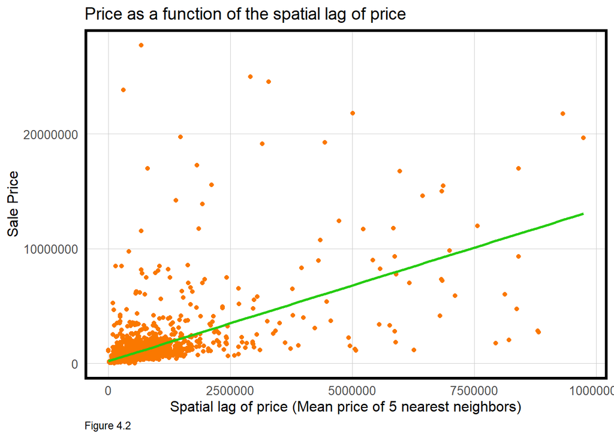

```r
# Adding in Spatial Correlation of Errors
Miami.testdistinct <- distinct (Miami.test,geometry,.keep_all=TRUE)
coords.test <-  st_coordinates(Miami.testdistinct)
neighborList.test <- knn2nb(knearneigh(coords.test, k_nearest_neighbors))
spatialWeights.test <- nb2listw(neighborList.test, style="W")
Miami.testdistinct$lagPriceError <- lag.listw(spatialWeights.test, Miami.testdistinct$SalePrice.AbsError)
ggplot(MiamiDFKnown, aes(x=lagPrice, y=SalePrice)) +
  geom_point(colour = "#FA7800") +
  geom_smooth(method = "lm", se = FALSE, colour = "#25CB10") +
  labs(title = "Price as a function of the spatial lag of price",
       caption = "Figure 4.2",
       x = "Spatial lag of price (Mean price of 5 nearest neighbors)",
       y = "Sale Price") +
  plotTheme()
```

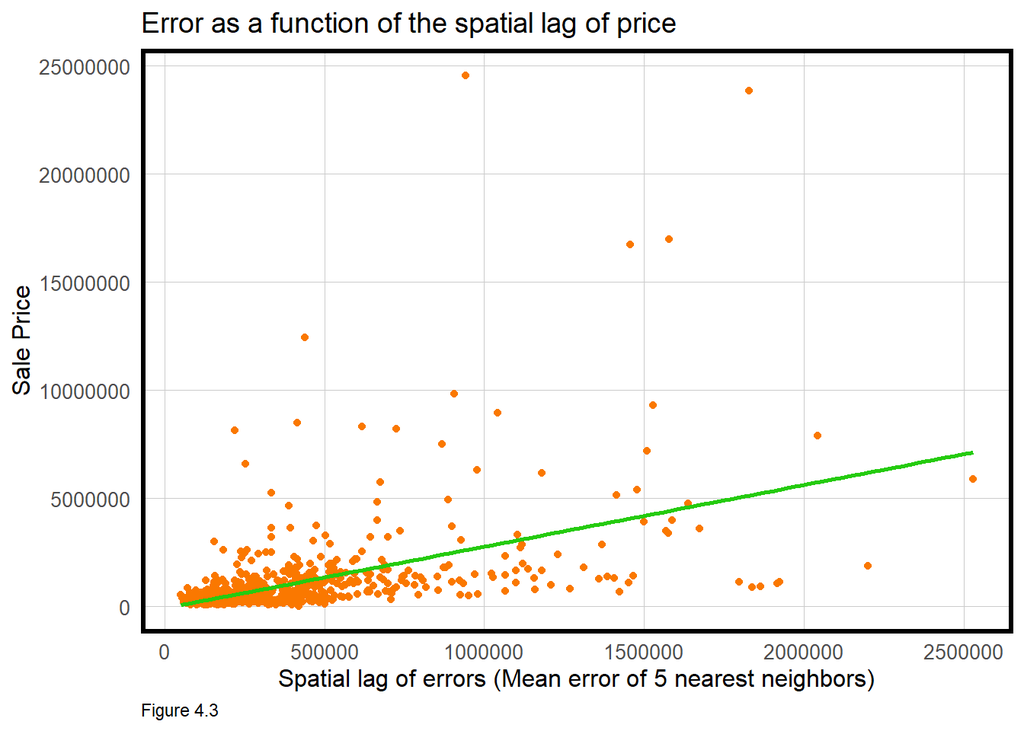

```r
ggplot(Miami.testdistinct, aes(x=lagPriceError, y=SalePrice)) +
  geom_point(colour = "#FA7800") +
  geom_smooth(method = "lm", se = FALSE, colour = "#25CB10") +
  labs(title = "Error as a function of the spatial lag of price",
       caption="Figure 4.3",
       x = "Spatial lag of errors (Mean error of 5 nearest neighbors)",
       y = "Sale Price") +
  plotTheme()
```

#### Moran I’s

Moran’s I provides another means of determining whether our errors are spatially correlated. Moran’s I here is positive, suggesting positive spatial autocorrelation in our model.

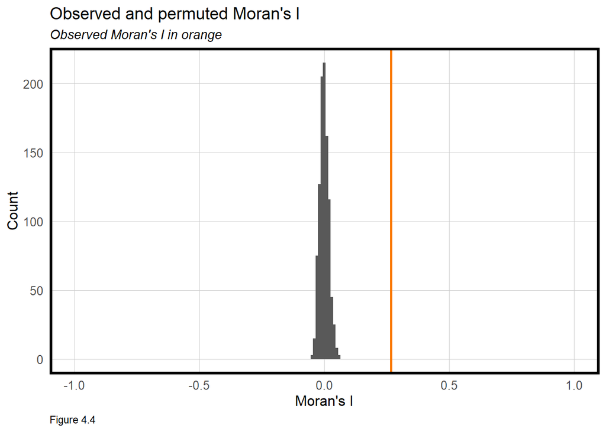

```r
# Moran's I
moranTest <- moran.mc(Miami.testdistinct$SalePrice.AbsError,
                      spatialWeights.test, nsim = 999)
ggplot(as.data.frame(moranTest$res[c(1:999)]), aes(moranTest$res[c(1:999)])) +
  geom_histogram(binwidth = 0.01) +
  geom_vline(aes(xintercept = moranTest$statistic), colour = "#FA7800",size=1) +
  scale_x_continuous(limits = c(-1, 1)) +
  labs(title="Observed and permuted Moran's I",
       subtitle= "Observed Moran's I in orange",
       x="Moran's I",
       y="Count",
       caption="Figure 4.4") +
  plotTheme()
```

#### Error by neighborhood

The second table demonstrates that our model performs better on Miami houses than on Miami Beach houses.

```r
# Errors by Group
nhood_sum <- Miami.test %>%
  group_by(Neighbourhood_name) %>%
  summarize(meanPrice = mean(SalePrice, na.rm = T),
            meanPrediction = mean(SalePrice.Predict, na.rm = T),
            meanMAE = mean(SalePrice.AbsError, na.rm = T))

nhood_sum %>%
  st_drop_geometry %>%
  arrange(desc(meanMAE)) %>%
  kable() %>% kable_styling()
```

| Neighbourhood_name | meanPrice | meanPrediction | meanMAE |
| --- | --- | --- | --- |
| Fair Isle | 1351250.0 | 2454506.6 | 1217466.60 |
| South Grove Bayside | 3718125.0 | 3242177.4 | 1157684.29 |
| MIAMI.BEACH.8 | 2910537.4 | 2910428.1 | 964252.82 |
| Palm Grove | 911400.0 | 1656649.2 | 745249.21 |
| Baypoint | 3195000.0 | 3123451.8 | 703136.42 |
| Bay Heights | 1250875.0 | 1190346.1 | 680391.44 |
| MIAMI.BEACH.6 | 1508058.8 | 1757176.5 | 505002.57 |
| East Grove | 1822863.2 | 1407615.5 | 475958.57 |
| Bird Grove East | 538333.3 | 960711.3 | 422378.01 |
| West Grove | 483825.0 | 647860.2 | 419906.88 |
| North Sewell Park | 334175.0 | 524655.6 | 394472.95 |
| Morningside | 940700.0 | 1034800.8 | 381091.56 |
| Belle Meade | 732694.1 | 624083.7 | 375042.00 |
| Shorecrest | 599991.3 | 550017.0 | 361243.39 |
| South Grove | 1311141.7 | 1309609.2 | 357220.56 |
| Miami Avenue | 1520000.0 | 1505716.0 | 340253.51 |
| North Grapeland Heights | 301871.4 | 101556.0 | 315684.18 |
| Roads | 626160.6 | 614119.8 | 280137.62 |
| South Sewell Park | 360500.0 | 513606.2 | 269001.77 |
| Little River Central | 247250.0 | 506597.0 | 259346.99 |
| La Pastorita | 317500.0 | 562838.9 | 245338.89 |
| Shenandoah South | 458442.9 | 582039.3 | 232010.16 |
| West Grapeland Heights | 304875.0 | 527631.7 | 230667.33 |
| Flagami | 335762.3 | 363393.0 | 230054.53 |
| Old San Juan | 717428.6 | 795527.6 | 229612.38 |
| North Grove | 961000.0 | 1041929.6 | 221931.45 |
| Edison | 218891.3 | 365218.2 | 220673.24 |
| Santa Clara | 223933.3 | 250264.4 | 215833.30 |
| Historic Buena Vista East | 730000.0 | 942325.5 | 212325.46 |
| South Grapeland Heights | 310214.3 | 385532.5 | 209218.11 |
| Curtis Park | 276666.7 | 477750.7 | 201084.01 |
| Douglas Park | 374892.9 | 337730.8 | 199074.82 |
| Parkdale North | 458500.0 | 656431.4 | 197931.36 |
| Liberty Square | 146100.0 | 122471.9 | 197864.49 |
| Flora Park | 166484.2 | 183763.8 | 197786.74 |
| Shenandoah North | 477625.0 | 549837.8 | 187213.02 |
| Buena Vista West | 302666.7 | 362060.7 | 184281.38 |
| Parkdale South | 416600.0 | 385394.2 | 180431.27 |
| Bird Grove West | 450000.0 | 269782.4 | 180217.58 |
| Orchard Villa | 234111.1 | 131382.5 | 174315.90 |
| Buena Vista Heights | 364742.9 | 521821.7 | 170733.40 |
| Silver Bluff | 492308.6 | 473923.9 | 165304.71 |
| East Little Havana | 281000.0 | 217502.5 | 156060.86 |
| Belle Meade West | 367916.7 | 430345.1 | 155289.76 |
| Hadley Park | 215189.8 | 185370.7 | 154069.24 |
| Auburndale | 329117.6 | 355614.6 | 153613.48 |
| Bayside | 629600.0 | 623811.8 | 145148.22 |
| Citrus Grove | 316378.9 | 231698.5 | 140372.64 |
| Coral Gate | 440750.0 | 510352.6 | 120860.72 |
| Northwestern Estates | 186772.7 | 231155.5 | 118581.94 |
| King Heights | 224250.0 | 208714.1 | 117826.34 |
| Melrose | 238300.0 | 163730.5 | 111800.99 |
| Lemon City/Little Haiti | 262428.6 | 294687.5 | 111018.73 |
| Allapattah Industrial District | 220000.0 | 111438.5 | 108561.47 |
| Latin Quarter | 255000.0 | 177690.8 | 77309.19 |

```r
# Errors by City
city_sum <- Miami.test %>%
  group_by(Property.City) %>%
  summarize(meanPrice = mean(SalePrice, na.rm = T),
            meanPrediction = mean(SalePrice.Predict, na.rm = T),
            meanMAE = mean(SalePrice.AbsError, na.rm = T))
city_sum %>%
  st_drop_geometry %>%
  arrange(desc(meanMAE)) %>%
  kable() %>% kable_styling()
```

| Property.City | meanPrice | meanPrediction | meanMAE |
| --- | --- | --- | --- |
| Miami Beach | 2749441.9 | 2777960.0 | 911501.1 |
| Miami | 565277.8 | 579796.4 | 257418.0 |

#### Map of Predicted Values

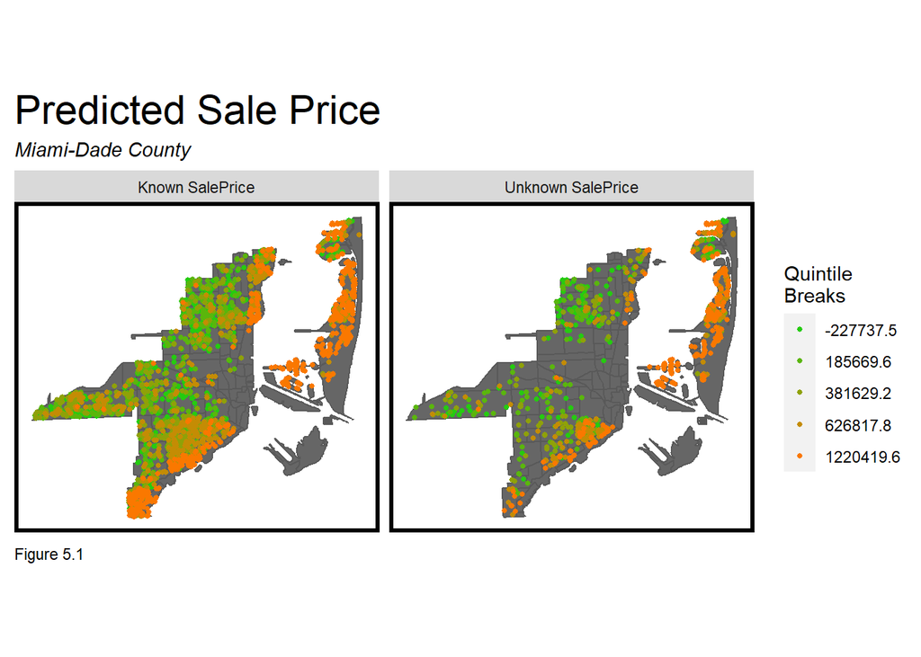

```r
MiamiDF$PredictedVal <- predict(reg, newdata = MiamiDF)
MiamiDF$Predict <- ifelse((MiamiDF$toPredict == 0), "Known SalePrice", "Unknown SalePrice")

ggplot() +
  geom_sf(data = Neighborhoods_combine, fill = "grey40") +
  geom_sf(data = MiamiDF, aes(colour = q5(PredictedVal)),
          show.legend = "point", size = 1) +
  scale_colour_manual(values=palette5,
                      labels=qBr(MiamiDF,"PredictedVal"),
                      name="Quintile\nBreaks") +
  facet_wrap(~Predict)+
  labs(title="Predicted Sale Price", subtitle = "Miami-Dade County", caption="Figure 5.1") +
  mapTheme()+
  theme(plot.title = element_text(size=22))
```

#### Map of MAPE by Neighborhood

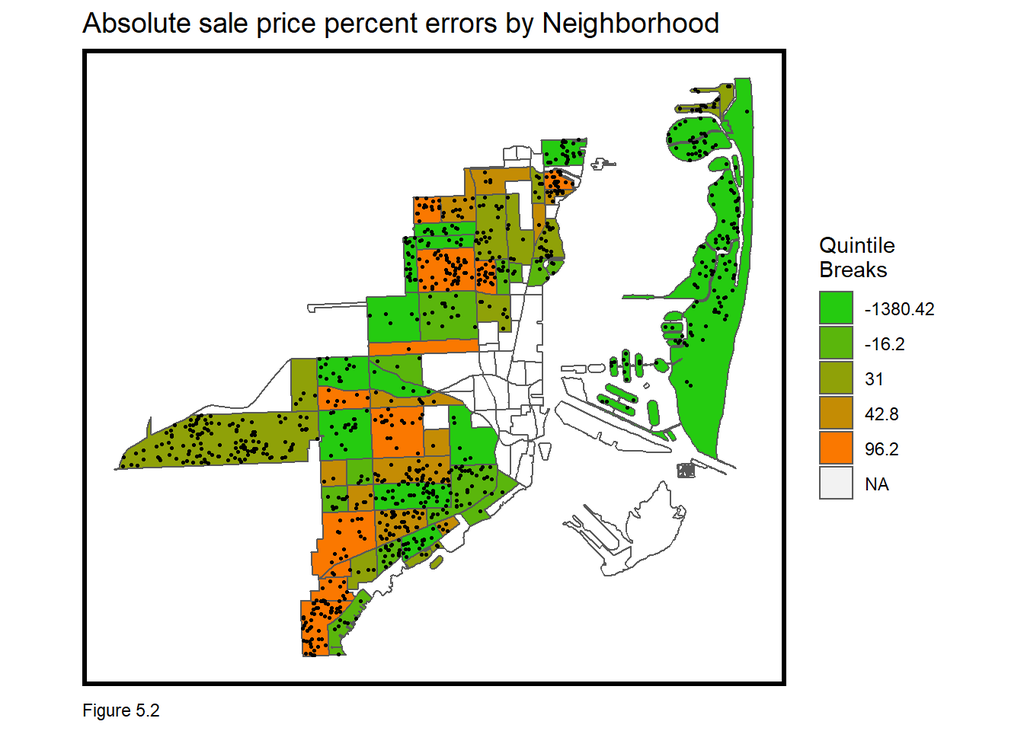

```r
map_preds_sum <- Miami.test %>%
  group_by(Neighbourhood_name) %>%
  summarise(meanMAPE = mean(SalePrice.APE)*100)

ggplot() +
  geom_sf(data = Neighborhoods_combine %>%
            left_join(st_drop_geometry(map_preds_sum), by = "Neighbourhood_name"),
          aes(fill = q5(meanMAPE))) +
  geom_sf(data = Miami.test, colour = "black", size = .5) +
  scale_fill_manual(values = palette5,
                    labels=qBr(map_preds_sum,"meanMAPE"),
                    name="Quintile\nBreaks") +
  mapTheme() +
  labs(title="Absolute sale price percent errors by Neighborhood", caption="Figure 5.2")
```

#### Scatterplot of MAPE by Neighborhood

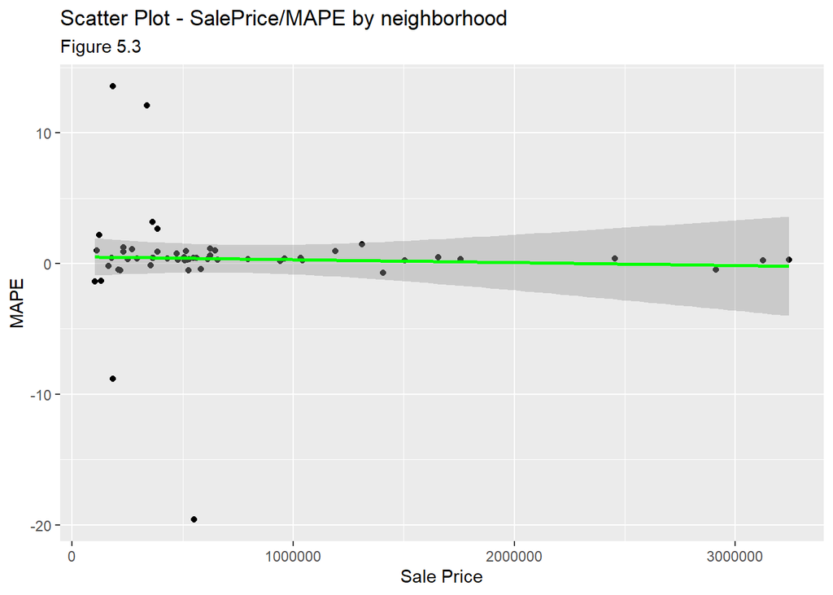

```r
map_preds_sum <- Miami.test %>%
  group_by(Neighbourhood_name) %>%
  summarise(meanMAPE = mean(SalePrice.APE),
            meanPrice = mean(SalePrice.Predict))


ggplot(map_preds_sum, aes(x = meanPrice, y = meanMAPE)) +
  geom_point() +
  geom_smooth(method = "lm", color = "green") +
  labs(title = "Scatter Plot - SalePrice/MAPE by neighborhood",
       x = "Sale Price",
       y = "MAPE",
       subtitle = "Figure 5.3") +
  theme(
    legend.position = "none"
  )
```

#### Generalization

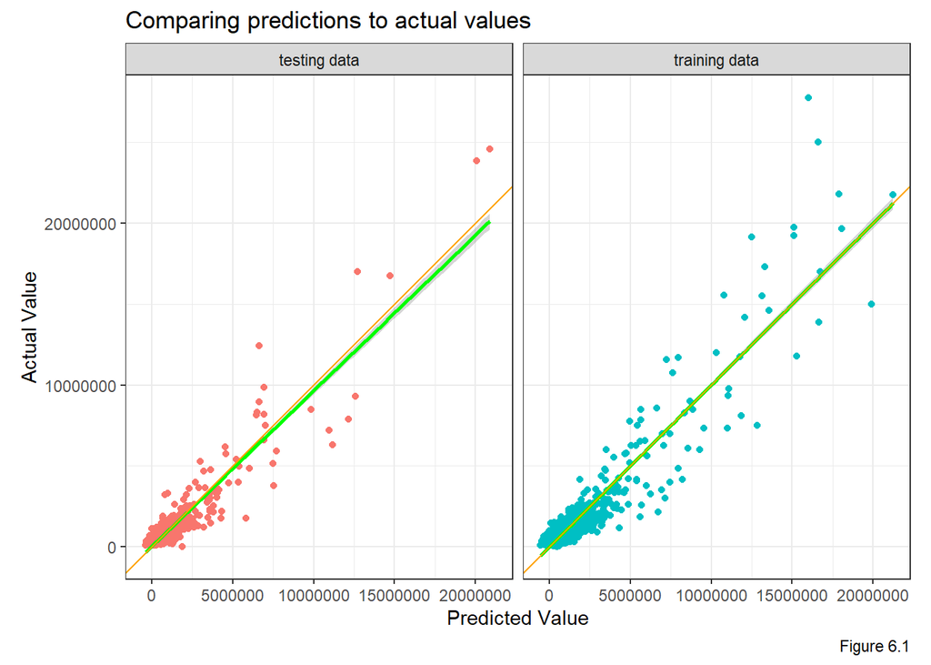

```r
# Measure Generalizability

# Plotting accuracy metrics
preds.train <- data.frame(pred   = predict(reg),
                          actual = Miami.training$SalePrice,
                          source = "training data")
preds.test  <- data.frame(pred   = reg_predict,
                          actual = Miami.test$SalePrice,
                          source = "testing data")
preds <- rbind(preds.train, preds.test)
ggplot(preds, aes(x = pred, y = actual, color = source)) +
  geom_point() +
  geom_smooth(method = "lm", color = "green") +
  geom_abline(color = "orange") +
  coord_equal() +
  theme_bw() +
  facet_wrap(~source, ncol = 2) +
  labs(title = "Comparing predictions to actual values",
       caption="Figure 6.1",
       x = "Predicted Value",
       y = "Actual Value") +
  theme(
    legend.position = "none"
  )
```

#### Cross Validation

```
## Linear Regression
##
## 2627 samples
##   32 predictor
##
## No pre-processing
## Resampling: Cross-Validated (100 fold)
## Summary of sample sizes: 2602, 2601, 2600, 2600, 2600, 2600, ...
## Resampling results:
##
##   RMSE      Rsquared   MAE
##   731697.3  0.8423277  377179.9
##
## Tuning parameter 'intercept' was held constant at a value of TRUE
```

#### Cross Validation Test Results

```r
data.frame(Test = c("Cross_Validation"),
           Mean = mean(reg.cv$resample[,3]),
           Max = max(reg.cv$resample[,3]),
           Min = min(reg.cv$resample[,3]),
           Standard_Deviation = sd(reg.cv$resample[,3]))%>%
  kable() %>%
  kable_styling() %>%
  footnote(general_title = "Summary Statistics of Cross Validation, k = 100 folds",
           general = "Table 3.1")
```

| Test | Mean | Max | Min | Standard_Deviation |
| --- | --- | --- | --- | --- |
| Cross_Validation | 377179.9 | 724162.3 | 188802.4 | 107925.3 |

Summary Statistics of Cross Validation, k = 100 folds  
Table 3.1

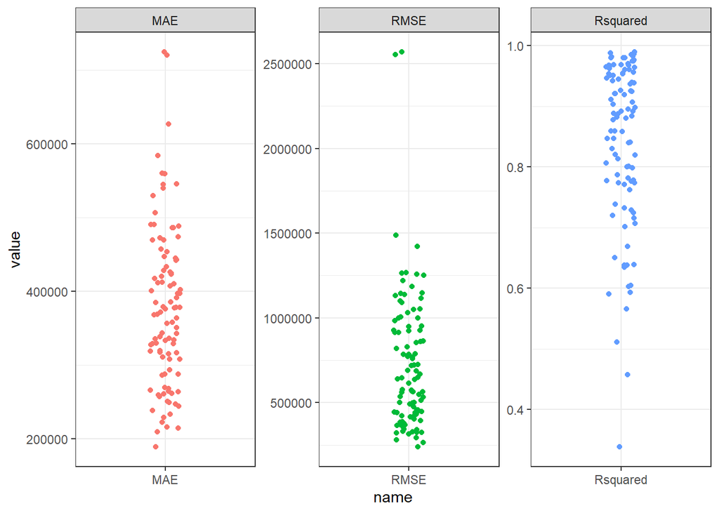

```r
reg.cv$resample %>%
  pivot_longer(-Resample) %>%
  mutate(name = as.factor(name)) %>%
  ggplot(., aes(x = name, y = value, color = name)) +
  geom_jitter(width = 0.1) +
  facet_wrap(~name, ncol = 3, scales = "free") +
  theme_bw() +
  theme(
    legend.position = "none"
  )
```

#### Histogram of MAE

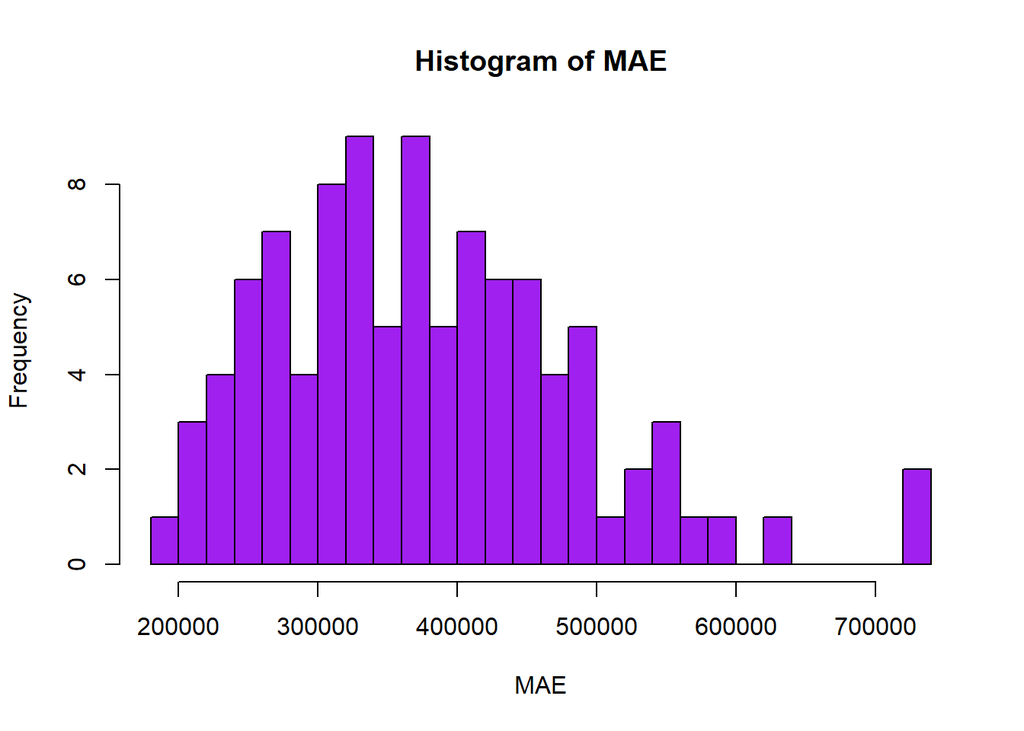

```r
hist(reg.cv$resample[,3],xlab="MAE", col="purple", breaks = 20, main = "Histogram of MAE")
```

#### Plot of Predicted Values

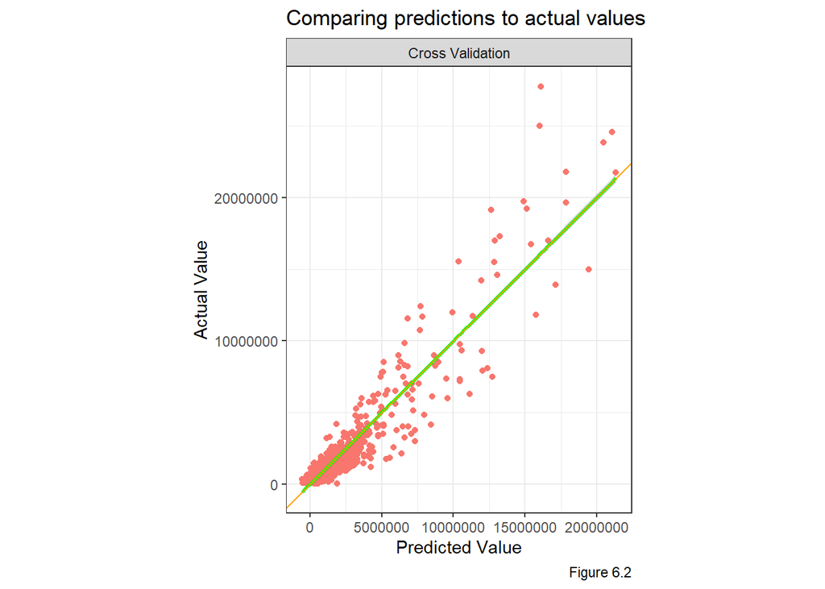

```r
preds        <- data.frame(pred   = predict(reg.cv),
                          actual = MiamiDFKnown$SalePrice,
                          source = "Cross Validation")
ggplot(preds, aes(x = pred, y = actual, color = source)) +
  geom_point() +
  geom_smooth(method = "lm", color = "green") +
  geom_abline(color = "orange") +
  coord_equal() +
  theme_bw() +
  facet_wrap(~source, ncol = 2) +
  labs(title = "Comparing predictions to actual values",
       caption="Figure 6.2",
       x = "Predicted Value",
       y = "Actual Value") +
  theme(
    legend.position = "none"
  )
```

#### Generalizability by Income

To further test the generalizability of the model, we calculated MAPE for below and above average census tracts. The results indicate that our model has larger percentage of absolute error in below average income census tracts when compared to above average income census tracts.

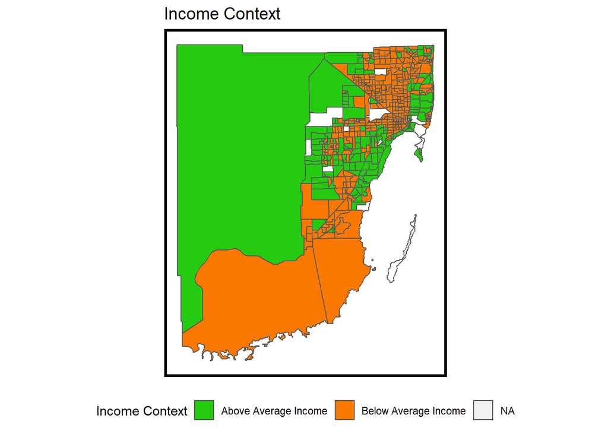

```r
Miamitracts <- Miamitracts %>%
  mutate(incomeContext = ifelse(MedHHInc > 59223.68, "Above Average Income", "Below Average Income") )

ggplot() + geom_sf(data = Miamitracts, aes(fill = incomeContext)) +
    scale_fill_manual(values = c("#25CB10", "#FA7800"), name="Income Context") +
    labs(title = "Income Context") +
    mapTheme() + theme(legend.position="bottom")
```

```r
st_join(Miami.test, Miamitracts) %>%
  group_by(incomeContext) %>%
  summarize(mean.MAPE = scales::percent(mean(SalePrice.APE, na.rm = T))) %>%
  st_drop_geometry() %>%
  spread(incomeContext, mean.MAPE) %>%
  kable(caption = "Test set MAPE by neighborhood income context")
```

Test set MAPE by neighborhood income context

| Above Average Income | Below Average Income |
| --- | --- |
| 28% | 65% |

# Discussion

Unfortunately our analysis suggests that the model is not as effective as we hoped. Our MAE was around $350,000, this magnitude of error would not be acceptable for Zillow’s Zestimate. We found that the adjusted square feet of a house is an important predictor for sale price, and we struggled to significantly improve the model beyond that variable. Based on our analysis of the spatial autocorrelations in our model, we are missing important spatial processes. We also suspect that key internal characteristics are missing and would have helped the model if we had access to them.

The lack of open source data for Miami Beach was a key barrier in the development of this model. Our model was unable to successfully predict sale prices for the very expensive houses in Miami Beach. Out of all the variables we used, the negative correlation of the distance to the coast and home sale prices was surprising to us.

# Conclusion

We would not recommend our model to Zillow given the large errors in our predictions and the lack of finding uniform data across all the neighborhoods. This model may be improved by additional spatial features.